# Forecasting NVIDIA’s Market Activity: A Time Series Analysis

Coursework 1 – 221112423

Govind Basra

Spring term 2025

# Introduction

In today’s fast-paced financial markets, understanding and anticipating stock behaviour is critical for investors, traders, and analysts. This study investigates the time series dynamics of NVIDIA (NVDA) by examining its adjusted stock prices, volatility, and trading volume. We use both new forecasting approaches (namely, Meta’s Prophet model) and traditional statistical methods like linear regression and STL decomposition. By integrating these methods, we want to not only estimate future trends but also break down the time series into its core components: trend, seasonality, and residuals.

# Data and Methodology

## Data Acquisition

Yahoo Finance was used to gather historical data on NVIDIA for this project. The dataset covers the period from January 1, 2015 to the present, and includes daily adjusted closing prices and trading volume. We calculated daily log returns and used a 30-day rolling window to estimate volatility. Our time series analyses are based on these measurements.

## Forecasting with Prophet

Prophet is a powerful forecasting tool that identifies patterns, seasonality, and holiday effects in time series data. In our investigation, we constructed distinct Prophet models for daily and monthly data.

- **Daily Forecasts:**  
  We used Prophet to predict daily volatility and trade volume. The projections include a shaded confidence interval, indicating the degree of uncertainty in our estimates. In addition, linear regression trends are overlayed on the historical data, acting as a baseline to validate Prophet’s forecasts.
- **Monthly Forecasts:**  
  Monthly Forecasts: To reduce noise, we aggregated daily data to a monthly level. This method highlights long-term seasonal trends while smoothing out short-term swings. Both average monthly volatility and total monthly trade volume are modeled and anticipated with Prophet.

## Classical Methods: Linear Regression and STL Decomposition

In addition to Prophet, we used linear regression on all charts to provide an intuitive view of long-term trends. Linear regression provides a simple baseline to compare against Prophet’s more sophisticated projections.

Furthermore, we used STL (Seasonal-Trend decomposition with Loess) on the monthly aggregates. The STL decomposition divides the time series into three components:

- **Trend:** The long-term movement.
- **Seasonal:** The repeating periodic fluctuations.
- **Residual:** The noise or irregular variation.

# Results and Visualisations

## Daily Analysis

### Stock Price

The first chart shows NVIDIA’s adjusted daily closing pricing. It incorporates two smoothing techniques:

- **Overlay:**
  - **LOESS Moving Average (Red Dashed):** Captures short-term trends.
  - **Linear Regression Trend (Green Dotted):** Highlights the overall long-term direction.

This visualisation shows how the stock price has changed over time. The moving average reduces the noise in daily data, and the linear regression trend indicates the overall rising or downward direction.

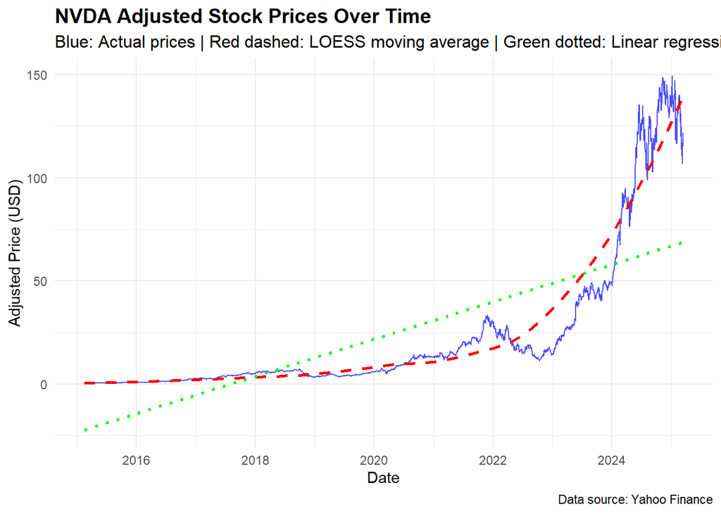

### Volatility & Trading Volume

The following chart depicts daily volatility, calculated as the 30-day rolling standard deviation of log returns. A linear regression trend (red dashed line) is overlayed to represent the long-term trend in market uncertainty.

### Volatility:

- **Chart:** Shows the 30-day rolling standard deviation of log returns.
- **Overlay:** Linear regression trend to indicate overall changes in market uncertainty.

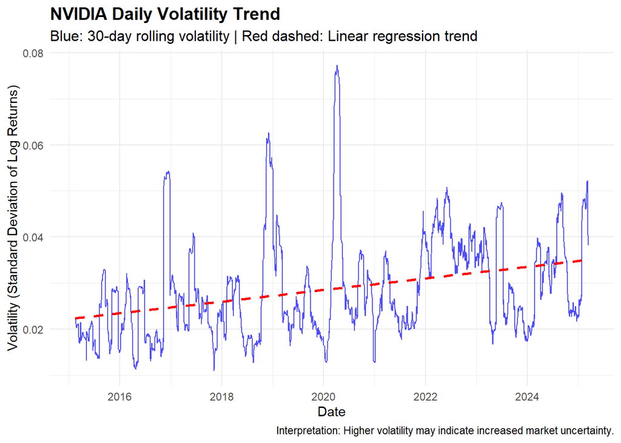

### Trading Volume:

This chart shows NVIDIA’s daily trading volume overlaid with a linear regression trend (red dashed line). Trading volume is an important measure of market activity and liquidity.

Changes in trade volume can indicate investor interest and market sentiment. An upward trend may imply increased market participation, whereas a downward trend may indicate dwindling investor interest.

- **Chart:** Reflects daily trading volume.
- **Overlay:** Linear regression trend to show long-term changes in investor activity.

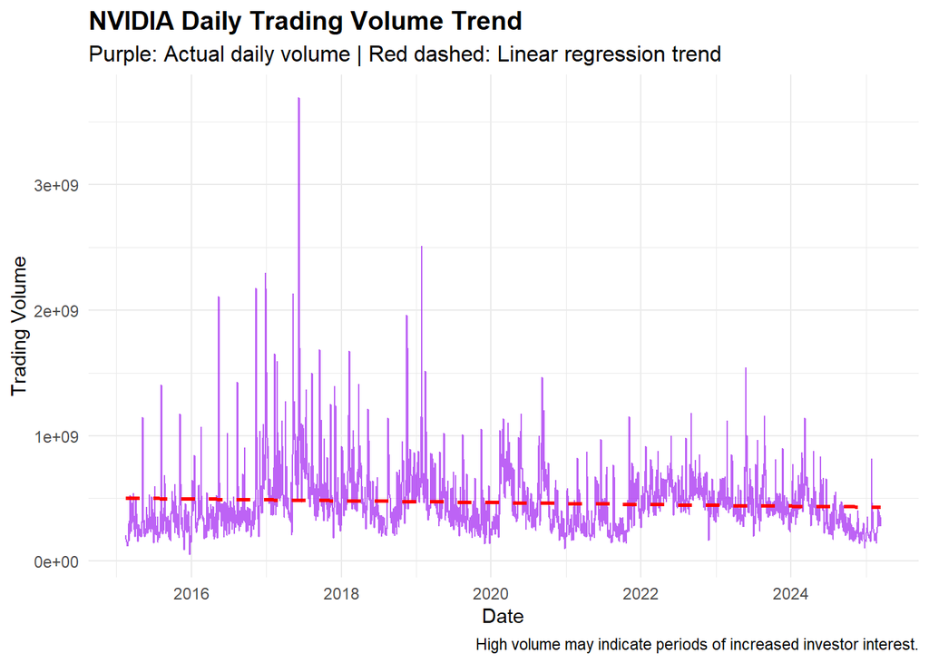

### Prophet Forecasts

#### Daily Forecasts: Volatility

Using Prophet, we forecast daily volatility over the following 180 days. The chart shows:

- **Blue Line:** The Prophet predicted volatility.
- **The shaded area:** represents the confidence interval surrounding the forecast.
- **The red dashed line:** is the historical linear regression trend for comparison.

The forecasting predicts market uncertainty in the near future. The confidence interval indicates the range within which actual volatility may fall, whilst the linear regression trend serves as a baseline to evaluate the forecast.

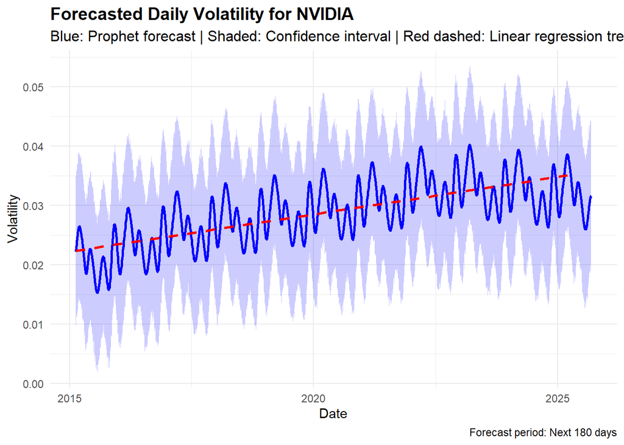

#### Daily Forecasts: Volume

Similarly, Prophet was used to estimate daily trading volume. The visualisation contains:

- **Purple Line:** The Prophet’s prediction of trade volume.
- **The shaded area:** represents the forecast’s confidence interval.
- **The red dashed line:** represents the historical linear regression trend.

This chart forecasts market activity for the following 180 days. It aids in identifying probable periods of high or low trading volume, which is useful for liquidity research and investing strategy.

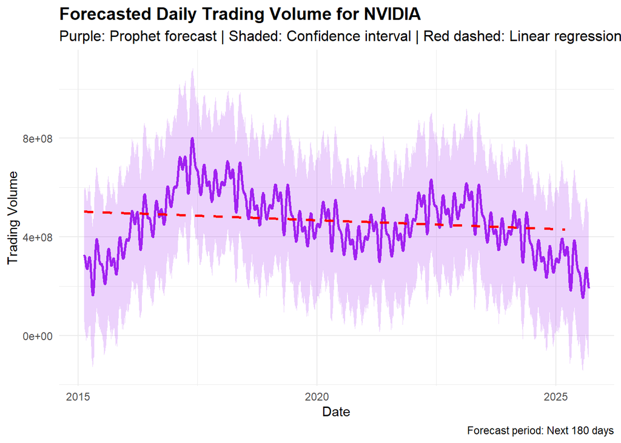

## Monthly Analysis

### Aggregated Metrics

By combining daily data into monthly figures, we can get smoother and more interpretable trends. Monthly analysis focuses on:

- **Average Volatility:** The average volatility for each month.
- **Total Trading Volume:** The aggregate of daily volumes for the entire month.
- **Monthly Volatility:**  
  The monthly volatility chart shows the aggregated average volatility as a linear regression trend (red dashed line).

This graphic highlights seasonal variations and long-term shifts in market uncertainty. The regression line clearly indicates whether volatility is growing or decreasing over time.

- **Monthly Trading Volume:**  
  The monthly trading volume chart sums the total volume for the month and overlays a linear regression trend.

This visualisation shows long-term investor activity trends. It is beneficial for analysing overall market liquidity trends and detecting seasonal spikes or decreases in trading activity.

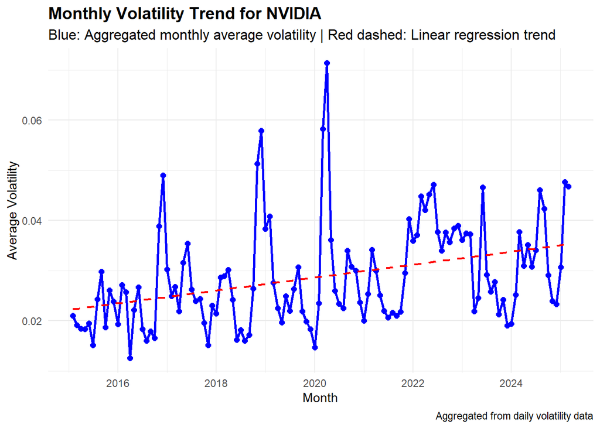

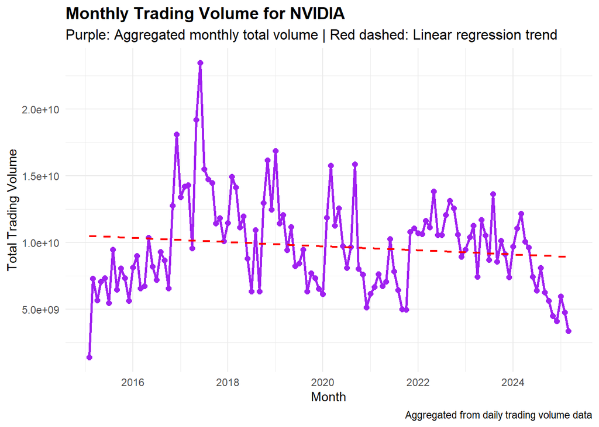

### Monthly Forecasts

The prophet estimates monthly volatility over the following 12 months. The chart contains:

- **Blue line:** represents the expected monthly volatility.
- **The shaded area:** is the Prophet’s confidence interval.
- **The red dashed line:** is the linear regression trend from past monthly data.

This projection presents a macro-level outlook on market uncertainty in the future year. The regression trend overlay is useful in determining whether the forecast is consistent with historical trends.

Similarly, Prophet forecasts monthly trading volume. The chart shows:

- **Purple Line:** The expected trade volume.
- **Shaded area:** represents the confidence interval.
- **The red dashed line:** represents the historical linear regression trend.

This graphic forecasts variations in trading activity over the following year, assisting investors and analysts in anticipating periods of greater or decreased market participation.

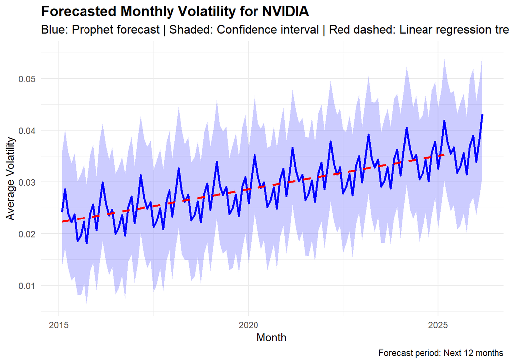

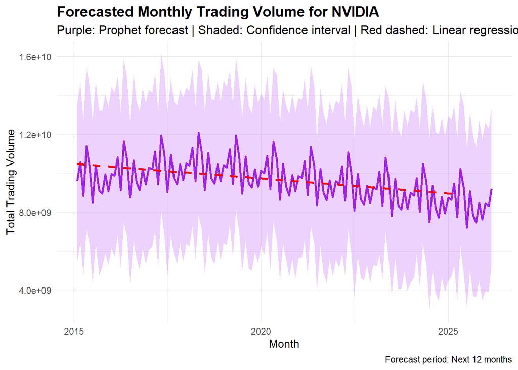

## Seasonal Decomposition

STL decomposition is used on monthly aggregated data to divide the time series into trend, seasonal, and residual components.

The Trend Component reveals the underlying long-term movement.

Seasonal Component: Displays repeated patterns throughout a one-year cycle. The seasonal amplitude (the difference between maximum and minimum) measures the magnitude of these seasonal changes.

The residual component captures random noise that is not explained by trend or seasonality.

For example, the decomposition of monthly average volatility demonstrates the cyclical character of market uncertainty, whereas the breakdown of monthly trading volume reveals seasonal fluctuations in investor behaviour.

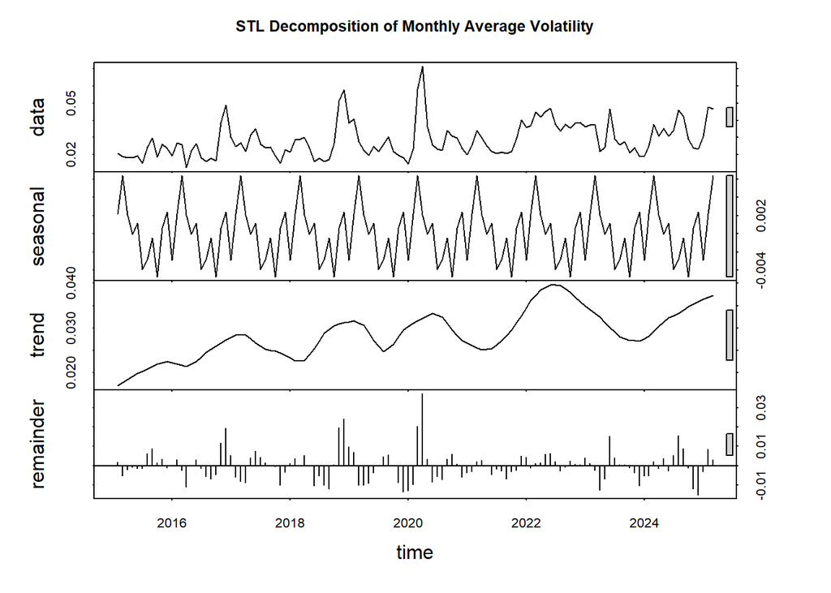

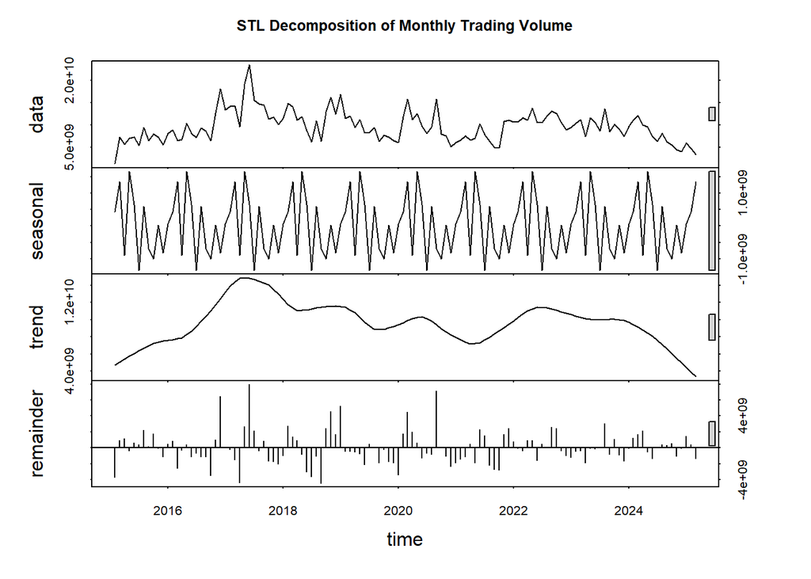

The seasonal amplitude (difference between maximum and minimum of the seasonal component) quantifies how large the seasonal variations are. This provides insight into the importance of seasonality in NVIDIA’s market behaviour.

# Conclusion

This time series research combines modern forecasting methods with traditional statistical analysis to provide a comprehensive view of NVIDIA’s market performance. The combination of Prophet forecasts, linear regression trends, and STL decomposition provides a multidimensional view of daily and monthly dynamics.

Detailed visualisations help to:

- Understand the historical evolution of stock prices, volatility, and trading volume
- Use confidence intervals and baseline comparisons to assess forecast reliability.
- Assess the impact of seasonal patterns on market behaviour.

# References

- Datacamp course: https://www.datacamp.com/courses/reporting-with-rmarkdown
- RStudio reference: https://rmarkdown.rstudio.com/lesson-1.html
- More sophisticated reference: https://bookdown.org/yihui/rmarkdown/
- Yahoo finance: https://uk.finance.yahoo.com/